# Risk Factor Analysis

## Outcome Variable

**Outcome Variable:** ever_stunted

## Predictor Variables

**Intervention Variable:** mhtcm

**Adjustment Set:**

unadjusted

## Stratifying Variables

The analysis was stratified on these variable(s):

- agecat
- studyid
- country

## Data Summary

| agecat | studyid | country | mhtcm | ever_stunted | n_cell | n |
| --- | --- | --- | --- | --- | --- | --- |
| 0-24 months | ki0047075b-MAL-ED | BANGLADESH | >=155 cm | 0 | 18 | 254 |
| 0-24 months | ki0047075b-MAL-ED | BANGLADESH | >=155 cm | 1 | 7 | 254 |
| 0-24 months | ki0047075b-MAL-ED | BANGLADESH | <151 cm | 0 | 45 | 254 |
| 0-24 months | ki0047075b-MAL-ED | BANGLADESH | <151 cm | 1 | 118 | 254 |
| 0-24 months | ki0047075b-MAL-ED | BANGLADESH | [151-155) cm | 0 | 36 | 254 |
| 0-24 months | ki0047075b-MAL-ED | BANGLADESH | [151-155) cm | 1 | 30 | 254 |
| 0-24 months | ki0047075b-MAL-ED | BRAZIL | >=155 cm | 0 | 104 | 222 |
| 0-24 months | ki0047075b-MAL-ED | BRAZIL | >=155 cm | 1 | 26 | 222 |
| 0-24 months | ki0047075b-MAL-ED | BRAZIL | <151 cm | 0 | 38 | 222 |
| 0-24 months | ki0047075b-MAL-ED | BRAZIL | <151 cm | 1 | 15 | 222 |
| 0-24 months | ki0047075b-MAL-ED | BRAZIL | [151-155) cm | 0 | 29 | 222 |
| 0-24 months | ki0047075b-MAL-ED | BRAZIL | [151-155) cm | 1 | 10 | 222 |
| 0-24 months | ki0047075b-MAL-ED | INDIA | >=155 cm | 0 | 33 | 242 |
| 0-24 months | ki0047075b-MAL-ED | INDIA | >=155 cm | 1 | 22 | 242 |
| 0-24 months | ki0047075b-MAL-ED | INDIA | <151 cm | 0 | 30 | 242 |
| 0-24 months | ki0047075b-MAL-ED | INDIA | <151 cm | 1 | 85 | 242 |
| 0-24 months | ki0047075b-MAL-ED | INDIA | [151-155) cm | 0 | 32 | 242 |
| 0-24 months | ki0047075b-MAL-ED | INDIA | [151-155) cm | 1 | 40 | 242 |
| 0-24 months | ki0047075b-MAL-ED | NEPAL | >=155 cm | 0 | 38 | 238 |
| 0-24 months | ki0047075b-MAL-ED | NEPAL | >=155 cm | 1 | 3 | 238 |
| 0-24 months | ki0047075b-MAL-ED | NEPAL | <151 cm | 0 | 75 | 238 |
| 0-24 months | ki0047075b-MAL-ED | NEPAL | <151 cm | 1 | 58 | 238 |
| 0-24 months | ki0047075b-MAL-ED | NEPAL | [151-155) cm | 0 | 43 | 238 |
| 0-24 months | ki0047075b-MAL-ED | NEPAL | [151-155) cm | 1 | 21 | 238 |
| 0-24 months | ki0047075b-MAL-ED | PERU | >=155 cm | 0 | 27 | 290 |
| 0-24 months | ki0047075b-MAL-ED | PERU | >=155 cm | 1 | 33 | 290 |
| 0-24 months | ki0047075b-MAL-ED | PERU | <151 cm | 0 | 53 | 290 |
| 0-24 months | ki0047075b-MAL-ED | PERU | <151 cm | 1 | 116 | 290 |
| 0-24 months | ki0047075b-MAL-ED | PERU | [151-155) cm | 0 | 24 | 290 |
| 0-24 months | ki0047075b-MAL-ED | PERU | [151-155) cm | 1 | 37 | 290 |

[output cut: 378 more lines]

The following strata were considered:

- agecat: 0-24 months, studyid: ki0047075b-MAL-ED, country: BANGLADESH
- agecat: 0-24 months, studyid: ki0047075b-MAL-ED, country: BRAZIL
- agecat: 0-24 months, studyid: ki0047075b-MAL-ED, country: INDIA
- agecat: 0-24 months, studyid: ki0047075b-MAL-ED, country: NEPAL
- agecat: 0-24 months, studyid: ki0047075b-MAL-ED, country: PERU
- agecat: 0-24 months, studyid: ki0047075b-MAL-ED, country: SOUTH AFRICA
- agecat: 0-24 months, studyid: ki0047075b-MAL-ED, country: TANZANIA, UNITED REPUBLIC OF
- agecat: 0-24 months, studyid: ki1000304b-SAS-CompFeed, country: INDIA
- agecat: 0-24 months, studyid: ki1000304b-SAS-FoodSuppl, country: INDIA
- agecat: 0-24 months, studyid: ki1017093-NIH-Birth, country: BANGLADESH
- agecat: 0-24 months, studyid: ki1017093b-PROVIDE, country: BANGLADESH
- agecat: 0-24 months, studyid: ki1017093c-NIH-Crypto, country: BANGLADESH
- agecat: 0-24 months, studyid: ki1066203-TanzaniaChild2, country: TANZANIA, UNITED REPUBLIC OF
- agecat: 0-24 months, studyid: ki1101329-Keneba, country: GAMBIA
- agecat: 0-24 months, studyid: ki1112895-Guatemala BSC, country: GUATEMALA
- agecat: 0-24 months, studyid: ki1112895-iLiNS-Zinc, country: BURKINA FASO
- agecat: 0-24 months, studyid: ki1119695-PROBIT, country: BELARUS
- agecat: 0-24 months, studyid: ki1126311-ZVITAMBO, country: ZIMBABWE
- agecat: 0-24 months, studyid: ki1135781-COHORTS, country: GUATEMALA
- agecat: 0-24 months, studyid: ki1135781-COHORTS, country: INDIA
- agecat: 0-24 months, studyid: ki1135781-COHORTS, country: PHILIPPINES
- agecat: 0-24 months, studyid: ki1148112-LCNI-5, country: MALAWI
- agecat: 0-24 months, studyid: kiGH5241-JiVitA-3, country: BANGLADESH
- agecat: 0-6 months, studyid: ki0047075b-MAL-ED, country: BANGLADESH
- agecat: 0-6 months, studyid: ki0047075b-MAL-ED, country: BRAZIL
- agecat: 0-6 months, studyid: ki0047075b-MAL-ED, country: INDIA
- agecat: 0-6 months, studyid: ki0047075b-MAL-ED, country: NEPAL
- agecat: 0-6 months, studyid: ki0047075b-MAL-ED, country: PERU
- agecat: 0-6 months, studyid: ki0047075b-MAL-ED, country: SOUTH AFRICA
- agecat: 0-6 months, studyid: ki0047075b-MAL-ED, country: TANZANIA, UNITED REPUBLIC OF
- agecat: 0-6 months, studyid: ki1000304b-SAS-CompFeed, country: INDIA
- agecat: 0-6 months, studyid: ki1000304b-SAS-FoodSuppl, country: INDIA
- agecat: 0-6 months, studyid: ki1017093-NIH-Birth, country: BANGLADESH
- agecat: 0-6 months, studyid: ki1017093b-PROVIDE, country: BANGLADESH
- agecat: 0-6 months, studyid: ki1017093c-NIH-Crypto, country: BANGLADESH
- agecat: 0-6 months, studyid: ki1066203-TanzaniaChild2, country: TANZANIA, UNITED REPUBLIC OF
- agecat: 0-6 months, studyid: ki1101329-Keneba, country: GAMBIA
- agecat: 0-6 months, studyid: ki1112895-Guatemala BSC, country: GUATEMALA
- agecat: 0-6 months, studyid: ki1119695-PROBIT, country: BELARUS
- agecat: 0-6 months, studyid: ki1126311-ZVITAMBO, country: ZIMBABWE
- agecat: 0-6 months, studyid: ki1135781-COHORTS, country: GUATEMALA
- agecat: 0-6 months, studyid: ki1135781-COHORTS, country: INDIA
- agecat: 0-6 months, studyid: ki1135781-COHORTS, country: PHILIPPINES
- agecat: 0-6 months, studyid: ki1148112-LCNI-5, country: MALAWI
- agecat: 0-6 months, studyid: kiGH5241-JiVitA-3, country: BANGLADESH
- agecat: 6-24 months, studyid: ki0047075b-MAL-ED, country: BANGLADESH
- agecat: 6-24 months, studyid: ki0047075b-MAL-ED, country: BRAZIL
- agecat: 6-24 months, studyid: ki0047075b-MAL-ED, country: INDIA
- agecat: 6-24 months, studyid: ki0047075b-MAL-ED, country: NEPAL
- agecat: 6-24 months, studyid: ki0047075b-MAL-ED, country: PERU
- agecat: 6-24 months, studyid: ki0047075b-MAL-ED, country: SOUTH AFRICA
- agecat: 6-24 months, studyid: ki0047075b-MAL-ED, country: TANZANIA, UNITED REPUBLIC OF
- agecat: 6-24 months, studyid: ki1000304b-SAS-CompFeed, country: INDIA
- agecat: 6-24 months, studyid: ki1000304b-SAS-FoodSuppl, country: INDIA
- agecat: 6-24 months, studyid: ki1017093-NIH-Birth, country: BANGLADESH
- agecat: 6-24 months, studyid: ki1017093b-PROVIDE, country: BANGLADESH
- agecat: 6-24 months, studyid: ki1017093c-NIH-Crypto, country: BANGLADESH
- agecat: 6-24 months, studyid: ki1066203-TanzaniaChild2, country: TANZANIA, UNITED REPUBLIC OF
- agecat: 6-24 months, studyid: ki1101329-Keneba, country: GAMBIA
- agecat: 6-24 months, studyid: ki1112895-Guatemala BSC, country: GUATEMALA
- agecat: 6-24 months, studyid: ki1112895-iLiNS-Zinc, country: BURKINA FASO
- agecat: 6-24 months, studyid: ki1119695-PROBIT, country: BELARUS
- agecat: 6-24 months, studyid: ki1126311-ZVITAMBO, country: ZIMBABWE
- agecat: 6-24 months, studyid: ki1135781-COHORTS, country: GUATEMALA
- agecat: 6-24 months, studyid: ki1135781-COHORTS, country: INDIA
- agecat: 6-24 months, studyid: ki1135781-COHORTS, country: PHILIPPINES
- agecat: 6-24 months, studyid: ki1148112-LCNI-5, country: MALAWI
- agecat: 6-24 months, studyid: kiGH5241-JiVitA-3, country: BANGLADESH

### Dropped Strata

Some strata were dropped due to rare outcomes:

- agecat: 0-24 months, studyid: ki0047075b-MAL-ED, country: NEPAL
- agecat: 0-24 months, studyid: ki0047075b-MAL-ED, country: TANZANIA, UNITED REPUBLIC OF
- agecat: 0-6 months, studyid: ki0047075b-MAL-ED, country: NEPAL
- agecat: 6-24 months, studyid: ki0047075b-MAL-ED, country: BANGLADESH
- agecat: 6-24 months, studyid: ki0047075b-MAL-ED, country: BRAZIL
- agecat: 6-24 months, studyid: ki0047075b-MAL-ED, country: NEPAL
- agecat: 6-24 months, studyid: ki0047075b-MAL-ED, country: TANZANIA, UNITED REPUBLIC OF

## Methods Detail

We’re interested in the causal parameters $E[Y_a]$ for all values of $a \in \mathcal{A}$. These parameters represent the mean outcome if, possibly contrary to fact, we intervened to set all units to have $A=a$. Under the randomization and positivity assumptions, these are identified by the statistical parameters $\psi_a=E_W[E_{Y|A,W}(Y|A=a,W)]$. In addition, we’re interested in the mean of $Y$, $E[Y]$ under no intervention (the observed mean). We will estimate these parameters by using SuperLearner to fit the relevant likelihood factors – $E_{Y|A,W}(Y|A=a,W)$ and $p(A=a|W)$, and then updating our likelihood fit using a joint TMLE.

For unadjusted analyses ($W=\{\}$), initial likelihoods were estimated using Lrnr_glm to estimate the simple $E(Y|A)$ and Lrnr_mean to estimate $p(A)$. For adjusted analyses, a small library containing Lrnr_glmnet, Lrnr_xgboost, and Lrnr_mean was used.

Having estimated these parameters, we will then use the delta method to estimate relative risks and attributable risks relative to a prespecified baseline level of $A$.

# Results Detail

## Results Plots

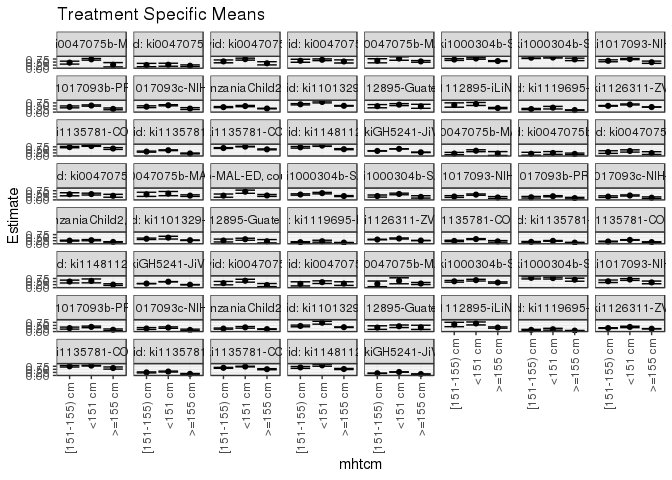

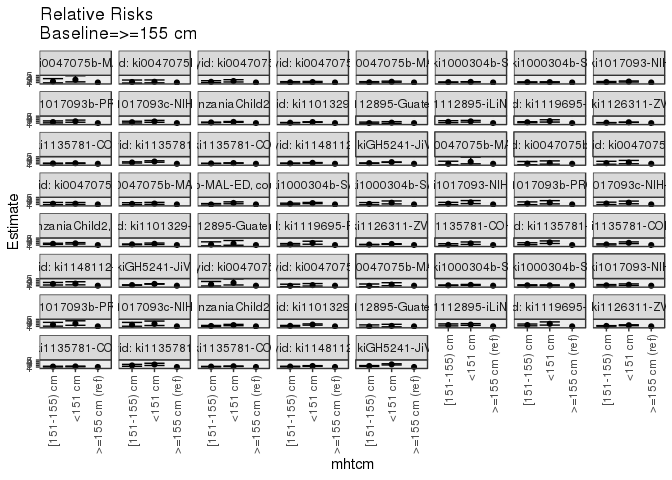

[figure not shown]

[figure not shown]

## Results Table

### Parameter: TSM

| agecat | studyid | country | intervention_level | baseline_level | estimate | ci_lower | ci_upper |
| --- | --- | --- | --- | --- | --- | --- | --- |
| 0-24 months | ki0047075b-MAL-ED | BANGLADESH | >=155 cm | NA | 0.2800000 | 0.1036482 | 0.4563518 |
| 0-24 months | ki0047075b-MAL-ED | BANGLADESH | <151 cm | NA | 0.7239264 | 0.6551609 | 0.7926919 |
| 0-24 months | ki0047075b-MAL-ED | BANGLADESH | [151-155) cm | NA | 0.4545455 | 0.3341803 | 0.5749106 |
| 0-24 months | ki0047075b-MAL-ED | BRAZIL | >=155 cm | NA | 0.2000000 | 0.1310845 | 0.2689155 |
| 0-24 months | ki0047075b-MAL-ED | BRAZIL | <151 cm | NA | 0.2830189 | 0.1614697 | 0.4045681 |
| 0-24 months | ki0047075b-MAL-ED | BRAZIL | [151-155) cm | NA | 0.2564103 | 0.1190597 | 0.3937608 |
| 0-24 months | ki0047075b-MAL-ED | INDIA | >=155 cm | NA | 0.4000000 | 0.2702607 | 0.5297393 |
| 0-24 months | ki0047075b-MAL-ED | INDIA | <151 cm | NA | 0.7391304 | 0.6587092 | 0.8195516 |
| 0-24 months | ki0047075b-MAL-ED | INDIA | [151-155) cm | NA | 0.5555556 | 0.4405408 | 0.6705703 |
| 0-24 months | ki0047075b-MAL-ED | PERU | >=155 cm | NA | 0.5500000 | 0.4239014 | 0.6760986 |
| 0-24 months | ki0047075b-MAL-ED | PERU | <151 cm | NA | 0.6863905 | 0.6163201 | 0.7564610 |
| 0-24 months | ki0047075b-MAL-ED | PERU | [151-155) cm | NA | 0.6065574 | 0.4837541 | 0.7293606 |
| 0-24 months | ki0047075b-MAL-ED | SOUTH AFRICA | >=155 cm | NA | 0.5539216 | 0.4855826 | 0.6222605 |
| 0-24 months | ki0047075b-MAL-ED | SOUTH AFRICA | <151 cm | NA | 0.7878788 | 0.6481395 | 0.9276181 |
| 0-24 months | ki0047075b-MAL-ED | SOUTH AFRICA | [151-155) cm | NA | 0.6060606 | 0.4390402 | 0.7730810 |
| 0-24 months | ki1000304b-SAS-CompFeed | INDIA | >=155 cm | NA | 0.5839161 | 0.5502379 | 0.6175943 |
| 0-24 months | ki1000304b-SAS-CompFeed | INDIA | <151 cm | NA | 0.7914980 | 0.7333544 | 0.8496416 |
| 0-24 months | ki1000304b-SAS-CompFeed | INDIA | [151-155) cm | NA | 0.7067449 | 0.6359440 | 0.7775458 |
| 0-24 months | ki1000304b-SAS-FoodSuppl | INDIA | >=155 cm | NA | 0.7179487 | 0.6179618 | 0.8179356 |
| 0-24 months | ki1000304b-SAS-FoodSuppl | INDIA | <151 cm | NA | 0.8727273 | 0.8286337 | 0.9168208 |
| 0-24 months | ki1000304b-SAS-FoodSuppl | INDIA | [151-155) cm | NA | 0.8558559 | 0.7904349 | 0.9212768 |
| 0-24 months | ki1017093-NIH-Birth | BANGLADESH | >=155 cm | NA | 0.4871795 | 0.3965378 | 0.5778211 |
| 0-24 months | ki1017093-NIH-Birth | BANGLADESH | <151 cm | NA | 0.7459016 | 0.7012647 | 0.7905386 |
| 0-24 months | ki1017093-NIH-Birth | BANGLADESH | [151-155) cm | NA | 0.6027397 | 0.5233033 | 0.6821761 |
| 0-24 months | ki1017093b-PROVIDE | BANGLADESH | >=155 cm | NA | 0.2608696 | 0.1875524 | 0.3341867 |
| 0-24 months | ki1017093b-PROVIDE | BANGLADESH | <151 cm | NA | 0.5335121 | 0.4828467 | 0.5841774 |
| 0-24 months | ki1017093b-PROVIDE | BANGLADESH | [151-155) cm | NA | 0.4240506 | 0.3469345 | 0.5011668 |
| 0-24 months | ki1017093c-NIH-Crypto | BANGLADESH | >=155 cm | NA | 0.2857143 | 0.2108329 | 0.3605957 |
| 0-24 months | ki1017093c-NIH-Crypto | BANGLADESH | <151 cm | NA | 0.5586207 | 0.5119273 | 0.6053141 |
| 0-24 months | ki1017093c-NIH-Crypto | BANGLADESH | [151-155) cm | NA | 0.4388889 | 0.3663449 | 0.5114329 |

[output cut: 153 more lines]

### Parameter: E(Y)

| agecat | studyid | country | intervention_level | baseline_level | estimate | ci_lower | ci_upper |
| --- | --- | --- | --- | --- | --- | --- | --- |
| 0-24 months | ki0047075b-MAL-ED | BANGLADESH | NA | NA | 0.6102362 | 0.5501413 | 0.6703311 |
| 0-24 months | ki0047075b-MAL-ED | BRAZIL | NA | NA | 0.2297297 | 0.1742694 | 0.2851900 |
| 0-24 months | ki0047075b-MAL-ED | INDIA | NA | NA | 0.6074380 | 0.5457864 | 0.6690897 |
| 0-24 months | ki0047075b-MAL-ED | PERU | NA | NA | 0.6413793 | 0.5860858 | 0.6966728 |
| 0-24 months | ki0047075b-MAL-ED | SOUTH AFRICA | NA | NA | 0.5888889 | 0.5300901 | 0.6476877 |
| 0-24 months | ki1000304b-SAS-CompFeed | INDIA | NA | NA | 0.6865672 | 0.6433613 | 0.7297731 |
| 0-24 months | ki1000304b-SAS-FoodSuppl | INDIA | NA | NA | 0.8386308 | 0.8029353 | 0.8743263 |
| 0-24 months | ki1017093-NIH-Birth | BANGLADESH | NA | NA | 0.6645469 | 0.6276196 | 0.7014742 |
| 0-24 months | ki1017093b-PROVIDE | BANGLADESH | NA | NA | 0.4514200 | 0.4136828 | 0.4891573 |
| 0-24 months | ki1017093c-NIH-Crypto | BANGLADESH | NA | NA | 0.4794702 | 0.4438115 | 0.5151289 |
| 0-24 months | ki1066203-TanzaniaChild2 | TANZANIA, UNITED REPUBLIC OF | NA | NA | 0.3454854 | 0.3262920 | 0.3646787 |
| 0-24 months | ki1101329-Keneba | GAMBIA | NA | NA | 0.5419753 | 0.5221615 | 0.5617891 |
| 0-24 months | ki1112895-Guatemala BSC | GUATEMALA | NA | NA | 0.5574468 | 0.4938076 | 0.6210860 |
| 0-24 months | ki1112895-iLiNS-Zinc | BURKINA FASO | NA | NA | 0.3559962 | 0.3060347 | 0.4059578 |
| 0-24 months | ki1119695-PROBIT | BELARUS | NA | NA | 0.1692151 | 0.1502685 | 0.1881616 |
| 0-24 months | ki1126311-ZVITAMBO | ZIMBABWE | NA | NA | 0.4388957 | 0.4290960 | 0.4486953 |
| 0-24 months | ki1135781-COHORTS | GUATEMALA | NA | NA | 0.7662539 | 0.7431681 | 0.7893396 |
| 0-24 months | ki1135781-COHORTS | INDIA | NA | NA | 0.3599161 | 0.3383625 | 0.3814696 |
| 0-24 months | ki1135781-COHORTS | PHILIPPINES | NA | NA | 0.6863963 | 0.6699497 | 0.7028430 |
| 0-24 months | ki1148112-LCNI-5 | MALAWI | NA | NA | 0.6356033 | 0.6029802 | 0.6682264 |
| 0-24 months | kiGH5241-JiVitA-3 | BANGLADESH | NA | NA | 0.4942495 | 0.4863870 | 0.5021120 |
| 0-6 months | ki0047075b-MAL-ED | BANGLADESH | NA | NA | 0.3464567 | 0.2878227 | 0.4050907 |
| 0-6 months | ki0047075b-MAL-ED | BRAZIL | NA | NA | 0.1891892 | 0.1375523 | 0.2408261 |
| 0-6 months | ki0047075b-MAL-ED | INDIA | NA | NA | 0.3429752 | 0.2830428 | 0.4029076 |
| 0-6 months | ki0047075b-MAL-ED | PERU | NA | NA | 0.4413793 | 0.3841309 | 0.4986278 |
| 0-6 months | ki0047075b-MAL-ED | SOUTH AFRICA | NA | NA | 0.3814815 | 0.3234338 | 0.4395292 |
| 0-6 months | ki0047075b-MAL-ED | TANZANIA, UNITED REPUBLIC OF | NA | NA | 0.4179687 | 0.3574314 | 0.4785061 |
| 0-6 months | ki1000304b-SAS-CompFeed | INDIA | NA | NA | 0.4266382 | 0.3925570 | 0.4607194 |
| 0-6 months | ki1000304b-SAS-FoodSuppl | INDIA | NA | NA | 0.3906634 | 0.3432048 | 0.4381220 |
| 0-6 months | ki1017093-NIH-Birth | BANGLADESH | NA | NA | 0.3497615 | 0.3124631 | 0.3870600 |
| 0-6 months | ki1017093b-PROVIDE | BANGLADESH | NA | NA | 0.2466368 | 0.2139486 | 0.2793250 |
| 0-6 months | ki1017093c-NIH-Crypto | BANGLADESH | NA | NA | 0.3033113 | 0.2704998 | 0.3361228 |
| 0-6 months | ki1066203-TanzaniaChild2 | TANZANIA, UNITED REPUBLIC OF | NA | NA | 0.1937262 | 0.1777743 | 0.2096780 |
| 0-6 months | ki1101329-Keneba | GAMBIA | NA | NA | 0.3141798 | 0.2945906 | 0.3337690 |
| 0-6 months | ki1112895-Guatemala BSC | GUATEMALA | NA | NA | 0.3196347 | 0.2577308 | 0.3815386 |
| 0-6 months | ki1119695-PROBIT | BELARUS | NA | NA | 0.0969856 | 0.0839703 | 0.1100009 |
| 0-6 months | ki1126311-ZVITAMBO | ZIMBABWE | NA | NA | 0.2859756 | 0.2770468 | 0.2949044 |
| 0-6 months | ki1135781-COHORTS | GUATEMALA | NA | NA | 0.3261682 | 0.2980650 | 0.3542714 |
| 0-6 months | ki1135781-COHORTS | INDIA | NA | NA | 0.1714744 | 0.1543953 | 0.1885534 |
| 0-6 months | ki1135781-COHORTS | PHILIPPINES | NA | NA | 0.2390451 | 0.2239262 | 0.2541640 |
| 0-6 months | ki1148112-LCNI-5 | MALAWI | NA | NA | 0.3579336 | 0.3007518 | 0.4151153 |
| 0-6 months | kiGH5241-JiVitA-3 | BANGLADESH | NA | NA | 0.4108991 | 0.4034353 | 0.4183630 |
| 6-24 months | ki0047075b-MAL-ED | INDIA | NA | NA | 0.4129032 | 0.3351414 | 0.4906651 |
| 6-24 months | ki0047075b-MAL-ED | PERU | NA | NA | 0.3918919 | 0.3129763 | 0.4708075 |
| 6-24 months | ki0047075b-MAL-ED | SOUTH AFRICA | NA | NA | 0.3589744 | 0.2834562 | 0.4344926 |
| 6-24 months | ki1000304b-SAS-CompFeed | INDIA | NA | NA | 0.4939435 | 0.4498186 | 0.5380683 |
| 6-24 months | ki1000304b-SAS-FoodSuppl | INDIA | NA | NA | 0.7572016 | 0.7031798 | 0.8112234 |
| 6-24 months | ki1017093-NIH-Birth | BANGLADESH | NA | NA | 0.5739130 | 0.5216565 | 0.6261696 |
| 6-24 months | ki1017093b-PROVIDE | BANGLADESH | NA | NA | 0.2997812 | 0.2577294 | 0.3418330 |
| 6-24 months | ki1017093c-NIH-Crypto | BANGLADESH | NA | NA | 0.2628458 | 0.2244546 | 0.3012371 |
| 6-24 months | ki1066203-TanzaniaChild2 | TANZANIA, UNITED REPUBLIC OF | NA | NA | 0.2268695 | 0.2061992 | 0.2475397 |
| 6-24 months | ki1101329-Keneba | GAMBIA | NA | NA | 0.3805837 | 0.3573526 | 0.4038147 |
| 6-24 months | ki1112895-Guatemala BSC | GUATEMALA | NA | NA | 0.3885350 | 0.3120482 | 0.4650219 |
| 6-24 months | ki1112895-iLiNS-Zinc | BURKINA FASO | NA | NA | 0.3559962 | 0.3060347 | 0.4059578 |
| 6-24 months | ki1119695-PROBIT | BELARUS | NA | NA | 0.0800387 | 0.0658162 | 0.0942612 |
| 6-24 months | ki1126311-ZVITAMBO | ZIMBABWE | NA | NA | 0.2439024 | 0.2332045 | 0.2546004 |
| 6-24 months | ki1135781-COHORTS | GUATEMALA | NA | NA | 0.7612827 | 0.7324712 | 0.7900941 |
| 6-24 months | ki1135781-COHORTS | INDIA | NA | NA | 0.2385621 | 0.2171991 | 0.2599251 |
| 6-24 months | ki1135781-COHORTS | PHILIPPINES | NA | NA | 0.6449788 | 0.6246093 | 0.6653483 |
| 6-24 months | ki1148112-LCNI-5 | MALAWI | NA | NA | 0.5983494 | 0.5626894 | 0.6340094 |
| 6-24 months | kiGH5241-JiVitA-3 | BANGLADESH | NA | NA | 0.2171835 | 0.2078204 | 0.2265466 |

### Parameter: RR

| agecat | studyid | country | intervention_level | baseline_level | estimate | ci_lower | ci_upper |
| --- | --- | --- | --- | --- | --- | --- | --- |
| 0-24 months | ki0047075b-MAL-ED | BANGLADESH | >=155 cm | >=155 cm | 1.0000000 | 1.0000000 | 1.000000 |
| 0-24 months | ki0047075b-MAL-ED | BANGLADESH | <151 cm | >=155 cm | 2.5854514 | 1.3674523 | 4.888331 |
| 0-24 months | ki0047075b-MAL-ED | BANGLADESH | [151-155) cm | >=155 cm | 1.6233766 | 0.8197776 | 3.214716 |
| 0-24 months | ki0047075b-MAL-ED | BRAZIL | >=155 cm | >=155 cm | 1.0000000 | 1.0000000 | 1.000000 |
| 0-24 months | ki0047075b-MAL-ED | BRAZIL | <151 cm | >=155 cm | 1.4150943 | 0.8159332 | 2.454235 |
| 0-24 months | ki0047075b-MAL-ED | BRAZIL | [151-155) cm | >=155 cm | 1.2820513 | 0.6780981 | 2.423920 |
| 0-24 months | ki0047075b-MAL-ED | INDIA | >=155 cm | >=155 cm | 1.0000000 | 1.0000000 | 1.000000 |
| 0-24 months | ki0047075b-MAL-ED | INDIA | <151 cm | >=155 cm | 1.8478261 | 1.3124535 | 2.601586 |
| 0-24 months | ki0047075b-MAL-ED | INDIA | [151-155) cm | >=155 cm | 1.3888889 | 0.9452708 | 2.040698 |
| 0-24 months | ki0047075b-MAL-ED | PERU | >=155 cm | >=155 cm | 1.0000000 | 1.0000000 | 1.000000 |
| 0-24 months | ki0047075b-MAL-ED | PERU | <151 cm | >=155 cm | 1.2479828 | 0.9709871 | 1.603998 |
| 0-24 months | ki0047075b-MAL-ED | PERU | [151-155) cm | >=155 cm | 1.1028316 | 0.8122185 | 1.497427 |
| 0-24 months | ki0047075b-MAL-ED | SOUTH AFRICA | >=155 cm | >=155 cm | 1.0000000 | 1.0000000 | 1.000000 |
| 0-24 months | ki0047075b-MAL-ED | SOUTH AFRICA | <151 cm | >=155 cm | 1.4223652 | 1.1459916 | 1.765391 |
| 0-24 months | ki0047075b-MAL-ED | SOUTH AFRICA | [151-155) cm | >=155 cm | 1.0941271 | 0.8089790 | 1.479784 |
| 0-24 months | ki1000304b-SAS-CompFeed | INDIA | >=155 cm | >=155 cm | 1.0000000 | 1.0000000 | 1.000000 |
| 0-24 months | ki1000304b-SAS-CompFeed | INDIA | <151 cm | >=155 cm | 1.3554995 | 1.2666059 | 1.450632 |
| 0-24 months | ki1000304b-SAS-CompFeed | INDIA | [151-155) cm | >=155 cm | 1.2103535 | 1.1239397 | 1.303411 |
| 0-24 months | ki1000304b-SAS-FoodSuppl | INDIA | >=155 cm | >=155 cm | 1.0000000 | 1.0000000 | 1.000000 |
| 0-24 months | ki1000304b-SAS-FoodSuppl | INDIA | <151 cm | >=155 cm | 1.2155844 | 1.0482018 | 1.409696 |
| 0-24 months | ki1000304b-SAS-FoodSuppl | INDIA | [151-155) cm | >=155 cm | 1.1920849 | 1.0169804 | 1.397339 |
| 0-24 months | ki1017093-NIH-Birth | BANGLADESH | >=155 cm | >=155 cm | 1.0000000 | 1.0000000 | 1.000000 |
| 0-24 months | ki1017093-NIH-Birth | BANGLADESH | <151 cm | >=155 cm | 1.5310613 | 1.2592546 | 1.861537 |
| 0-24 months | ki1017093-NIH-Birth | BANGLADESH | [151-155) cm | >=155 cm | 1.2372026 | 0.9849643 | 1.554036 |
| 0-24 months | ki1017093b-PROVIDE | BANGLADESH | >=155 cm | >=155 cm | 1.0000000 | 1.0000000 | 1.000000 |
| 0-24 months | ki1017093b-PROVIDE | BANGLADESH | <151 cm | >=155 cm | 2.0451296 | 1.5201382 | 2.751431 |
| 0-24 months | ki1017093b-PROVIDE | BANGLADESH | [151-155) cm | >=155 cm | 1.6255274 | 1.1630878 | 2.271831 |
| 0-24 months | ki1017093c-NIH-Crypto | BANGLADESH | >=155 cm | >=155 cm | 1.0000000 | 1.0000000 | 1.000000 |
| 0-24 months | ki1017093c-NIH-Crypto | BANGLADESH | <151 cm | >=155 cm | 1.9551724 | 1.4849588 | 2.574280 |
| 0-24 months | ki1017093c-NIH-Crypto | BANGLADESH | [151-155) cm | >=155 cm | 1.5361111 | 1.1268209 | 2.094066 |

[output cut: 153 more lines]

### Parameter: PAR

| agecat | studyid | country | intervention_level | baseline_level | estimate | ci_lower | ci_upper |
| --- | --- | --- | --- | --- | --- | --- | --- |
| 0-24 months | ki0047075b-MAL-ED | BANGLADESH | >=155 cm | NA | 0.3302362 | 0.1611525 | 0.4993200 |
| 0-24 months | ki0047075b-MAL-ED | BRAZIL | >=155 cm | NA | 0.0297297 | -0.0178401 | 0.0772996 |
| 0-24 months | ki0047075b-MAL-ED | INDIA | >=155 cm | NA | 0.2074380 | 0.0934987 | 0.3213773 |
| 0-24 months | ki0047075b-MAL-ED | PERU | >=155 cm | NA | 0.0913793 | -0.0198797 | 0.2026383 |
| 0-24 months | ki0047075b-MAL-ED | SOUTH AFRICA | >=155 cm | NA | 0.0349673 | 0.0022519 | 0.0676827 |
| 0-24 months | ki1000304b-SAS-CompFeed | INDIA | >=155 cm | NA | 0.1026511 | 0.0818388 | 0.1234634 |
| 0-24 months | ki1000304b-SAS-FoodSuppl | INDIA | >=155 cm | NA | 0.1206821 | 0.0343202 | 0.2070439 |
| 0-24 months | ki1017093-NIH-Birth | BANGLADESH | >=155 cm | NA | 0.1773674 | 0.0966020 | 0.2581329 |
| 0-24 months | ki1017093b-PROVIDE | BANGLADESH | >=155 cm | NA | 0.1905505 | 0.1228611 | 0.2582398 |
| 0-24 months | ki1017093c-NIH-Crypto | BANGLADESH | >=155 cm | NA | 0.1937559 | 0.1244792 | 0.2630327 |
| 0-24 months | ki1066203-TanzaniaChild2 | TANZANIA, UNITED REPUBLIC OF | >=155 cm | NA | 0.0555525 | 0.0404329 | 0.0706721 |
| 0-24 months | ki1101329-Keneba | GAMBIA | >=155 cm | NA | 0.0287978 | 0.0198642 | 0.0377314 |
| 0-24 months | ki1112895-Guatemala BSC | GUATEMALA | >=155 cm | NA | 0.0852246 | -0.0650257 | 0.2354749 |
| 0-24 months | ki1112895-iLiNS-Zinc | BURKINA FASO | >=155 cm | NA | 0.0269707 | 0.0165874 | 0.0373540 |
| 0-24 months | ki1119695-PROBIT | BELARUS | >=155 cm | NA | 0.0042011 | 0.0025992 | 0.0058030 |
| 0-24 months | ki1126311-ZVITAMBO | ZIMBABWE | >=155 cm | NA | 0.0264706 | 0.0213911 | 0.0315501 |
| 0-24 months | ki1135781-COHORTS | GUATEMALA | >=155 cm | NA | 0.1578201 | 0.0897566 | 0.2258837 |
| 0-24 months | ki1135781-COHORTS | INDIA | >=155 cm | NA | 0.1550124 | 0.1249437 | 0.1850811 |
| 0-24 months | ki1135781-COHORTS | PHILIPPINES | >=155 cm | NA | 0.1452571 | 0.1112540 | 0.1792602 |
| 0-24 months | ki1148112-LCNI-5 | MALAWI | >=155 cm | NA | 0.0811286 | 0.0557819 | 0.1064754 |
| 0-24 months | kiGH5241-JiVitA-3 | BANGLADESH | >=155 cm | NA | 0.1962977 | 0.1817616 | 0.2108338 |
| 0-6 months | ki0047075b-MAL-ED | BANGLADESH | >=155 cm | NA | 0.1464567 | -0.0060612 | 0.2989745 |
| 0-6 months | ki0047075b-MAL-ED | BRAZIL | >=155 cm | NA | 0.0199584 | -0.0242233 | 0.0641402 |
| 0-6 months | ki0047075b-MAL-ED | INDIA | >=155 cm | NA | 0.1066116 | 0.0041577 | 0.2090655 |
| 0-6 months | ki0047075b-MAL-ED | PERU | >=155 cm | NA | 0.1080460 | 0.0001267 | 0.2159653 |
| 0-6 months | ki0047075b-MAL-ED | SOUTH AFRICA | >=155 cm | NA | 0.0334423 | -0.0008728 | 0.0677574 |
| 0-6 months | ki0047075b-MAL-ED | TANZANIA, UNITED REPUBLIC OF | >=155 cm | NA | 0.0584916 | 0.0081804 | 0.1088028 |
| 0-6 months | ki1000304b-SAS-CompFeed | INDIA | >=155 cm | NA | 0.1149044 | 0.0770443 | 0.1527644 |
| 0-6 months | ki1000304b-SAS-FoodSuppl | INDIA | >=155 cm | NA | 0.1470736 | 0.0584037 | 0.2357436 |
| 0-6 months | ki1017093-NIH-Birth | BANGLADESH | >=155 cm | NA | 0.1531803 | 0.0849690 | 0.2213916 |
| 0-6 months | ki1017093b-PROVIDE | BANGLADESH | >=155 cm | NA | 0.1017092 | 0.0460495 | 0.1573690 |
| 0-6 months | ki1017093c-NIH-Crypto | BANGLADESH | >=155 cm | NA | 0.1247398 | 0.0646387 | 0.1848409 |
| 0-6 months | ki1066203-TanzaniaChild2 | TANZANIA, UNITED REPUBLIC OF | >=155 cm | NA | 0.0447329 | 0.0317571 | 0.0577087 |
| 0-6 months | ki1101329-Keneba | GAMBIA | >=155 cm | NA | 0.0228149 | 0.0133076 | 0.0323222 |
| 0-6 months | ki1112895-Guatemala BSC | GUATEMALA | >=155 cm | NA | 0.1137524 | -0.0151939 | 0.2426986 |
| 0-6 months | ki1119695-PROBIT | BELARUS | >=155 cm | NA | 0.0020647 | 0.0009860 | 0.0031434 |
| 0-6 months | ki1126311-ZVITAMBO | ZIMBABWE | >=155 cm | NA | 0.0214199 | 0.0165997 | 0.0262402 |
| 0-6 months | ki1135781-COHORTS | GUATEMALA | >=155 cm | NA | 0.1305161 | 0.0669270 | 0.1941051 |
| 0-6 months | ki1135781-COHORTS | INDIA | >=155 cm | NA | 0.0784511 | 0.0555307 | 0.1013715 |
| 0-6 months | ki1135781-COHORTS | PHILIPPINES | >=155 cm | NA | 0.1029692 | 0.0775150 | 0.1284234 |
| 0-6 months | ki1148112-LCNI-5 | MALAWI | >=155 cm | NA | 0.1094864 | 0.0602094 | 0.1587634 |
| 0-6 months | kiGH5241-JiVitA-3 | BANGLADESH | >=155 cm | NA | 0.1703684 | 0.1564871 | 0.1842497 |
| 6-24 months | ki0047075b-MAL-ED | INDIA | >=155 cm | NA | 0.1986175 | 0.0839587 | 0.3132763 |
| 6-24 months | ki0047075b-MAL-ED | PERU | >=155 cm | NA | 0.0585586 | -0.0704796 | 0.1875967 |
| 6-24 months | ki0047075b-MAL-ED | SOUTH AFRICA | >=155 cm | NA | 0.0202647 | -0.0195397 | 0.0600691 |
| 6-24 months | ki1000304b-SAS-CompFeed | INDIA | >=155 cm | NA | 0.0745886 | 0.0359773 | 0.1131999 |
| 6-24 months | ki1000304b-SAS-FoodSuppl | INDIA | >=155 cm | NA | 0.1080788 | 0.0027190 | 0.2134387 |
| 6-24 months | ki1017093-NIH-Birth | BANGLADESH | >=155 cm | NA | 0.1435333 | 0.0475595 | 0.2395071 |
| 6-24 months | ki1017093b-PROVIDE | BANGLADESH | >=155 cm | NA | 0.1529922 | 0.0891035 | 0.2168809 |
| 6-24 months | ki1017093c-NIH-Crypto | BANGLADESH | >=155 cm | NA | 0.1301025 | 0.0697385 | 0.1904665 |
| 6-24 months | ki1066203-TanzaniaChild2 | TANZANIA, UNITED REPUBLIC OF | >=155 cm | NA | 0.0274393 | 0.0121995 | 0.0426790 |
| 6-24 months | ki1101329-Keneba | GAMBIA | >=155 cm | NA | 0.0236412 | 0.0132761 | 0.0340063 |
| 6-24 months | ki1112895-Guatemala BSC | GUATEMALA | >=155 cm | NA | 0.0437074 | -0.1139062 | 0.2013210 |
| 6-24 months | ki1112895-iLiNS-Zinc | BURKINA FASO | >=155 cm | NA | 0.0269707 | 0.0165874 | 0.0373540 |
| 6-24 months | ki1119695-PROBIT | BELARUS | >=155 cm | NA | 0.0025427 | 0.0012160 | 0.0038694 |
| 6-24 months | ki1126311-ZVITAMBO | ZIMBABWE | >=155 cm | NA | 0.0145465 | 0.0091409 | 0.0199520 |
| 6-24 months | ki1135781-COHORTS | GUATEMALA | >=155 cm | NA | 0.1547253 | 0.0761555 | 0.2332951 |
| 6-24 months | ki1135781-COHORTS | INDIA | >=155 cm | NA | 0.1077774 | 0.0801296 | 0.1354252 |
| 6-24 months | ki1135781-COHORTS | PHILIPPINES | >=155 cm | NA | 0.1340007 | 0.0962354 | 0.1717661 |
| 6-24 months | ki1148112-LCNI-5 | MALAWI | >=155 cm | NA | 0.0725983 | 0.0463066 | 0.0988900 |
| 6-24 months | kiGH5241-JiVitA-3 | BANGLADESH | >=155 cm | NA | 0.1047422 | 0.0906448 | 0.1188397 |

### Parameter: PAF

| agecat | studyid | country | intervention_level | baseline_level | estimate | ci_lower | ci_upper |
| --- | --- | --- | --- | --- | --- | --- | --- |
| 0-24 months | ki0047075b-MAL-ED | BANGLADESH | >=155 cm | NA | 0.5411613 | 0.1566110 | 0.7503727 |
| 0-24 months | ki0047075b-MAL-ED | BRAZIL | >=155 cm | NA | 0.1294118 | -0.1029168 | 0.3128005 |
| 0-24 months | ki0047075b-MAL-ED | INDIA | >=155 cm | NA | 0.3414966 | 0.1200885 | 0.5071928 |
| 0-24 months | ki0047075b-MAL-ED | PERU | >=155 cm | NA | 0.1424731 | -0.0508842 | 0.3002537 |
| 0-24 months | ki0047075b-MAL-ED | SOUTH AFRICA | >=155 cm | NA | 0.0593785 | 0.0015845 | 0.1138270 |
| 0-24 months | ki1000304b-SAS-CompFeed | INDIA | >=155 cm | NA | 0.1495135 | 0.1238821 | 0.1743951 |
| 0-24 months | ki1000304b-SAS-FoodSuppl | INDIA | >=155 cm | NA | 0.1439037 | 0.0328617 | 0.2421965 |
| 0-24 months | ki1017093-NIH-Birth | BANGLADESH | >=155 cm | NA | 0.2668998 | 0.1326881 | 0.3803429 |
| 0-24 months | ki1017093b-PROVIDE | BANGLADESH | >=155 cm | NA | 0.4221134 | 0.2511777 | 0.5540292 |
| 0-24 months | ki1017093c-NIH-Crypto | BANGLADESH | >=155 cm | NA | 0.4041042 | 0.2402064 | 0.5326470 |
| 0-24 months | ki1066203-TanzaniaChild2 | TANZANIA, UNITED REPUBLIC OF | >=155 cm | NA | 0.1607955 | 0.1159807 | 0.2033384 |
| 0-24 months | ki1101329-Keneba | GAMBIA | >=155 cm | NA | 0.0531349 | 0.0363633 | 0.0696146 |
| 0-24 months | ki1112895-Guatemala BSC | GUATEMALA | >=155 cm | NA | 0.1528838 | -0.1653428 | 0.3842105 |
| 0-24 months | ki1112895-iLiNS-Zinc | BURKINA FASO | >=155 cm | NA | 0.0757613 | 0.0425255 | 0.1078433 |
| 0-24 months | ki1119695-PROBIT | BELARUS | >=155 cm | NA | 0.0248269 | 0.0150490 | 0.0345077 |
| 0-24 months | ki1126311-ZVITAMBO | ZIMBABWE | >=155 cm | NA | 0.0603118 | 0.0486297 | 0.0718505 |
| 0-24 months | ki1135781-COHORTS | GUATEMALA | >=155 cm | NA | 0.2059632 | 0.1109630 | 0.2908120 |
| 0-24 months | ki1135781-COHORTS | INDIA | >=155 cm | NA | 0.4306904 | 0.3423767 | 0.5071442 |
| 0-24 months | ki1135781-COHORTS | PHILIPPINES | >=155 cm | NA | 0.2116228 | 0.1598213 | 0.2602304 |
| 0-24 months | ki1148112-LCNI-5 | MALAWI | >=155 cm | NA | 0.1276404 | 0.0857003 | 0.1676566 |
| 0-24 months | kiGH5241-JiVitA-3 | BANGLADESH | >=155 cm | NA | 0.3971631 | 0.3670654 | 0.4258297 |
| 0-6 months | ki0047075b-MAL-ED | BANGLADESH | >=155 cm | NA | 0.4227273 | -0.2327309 | 0.7296703 |
| 0-6 months | ki0047075b-MAL-ED | BRAZIL | >=155 cm | NA | 0.1054945 | -0.1600130 | 0.3102318 |
| 0-6 months | ki0047075b-MAL-ED | INDIA | >=155 cm | NA | 0.3108434 | -0.0609421 | 0.5523442 |
| 0-6 months | ki0047075b-MAL-ED | PERU | >=155 cm | NA | 0.2447917 | -0.0444849 | 0.4539513 |
| 0-6 months | ki0047075b-MAL-ED | SOUTH AFRICA | >=155 cm | NA | 0.0876642 | -0.0070086 | 0.1734365 |
| 0-6 months | ki0047075b-MAL-ED | TANZANIA, UNITED REPUBLIC OF | >=155 cm | NA | 0.1399426 | 0.0102803 | 0.2526179 |
| 0-6 months | ki1000304b-SAS-CompFeed | INDIA | >=155 cm | NA | 0.2693251 | 0.1825100 | 0.3469207 |
| 0-6 months | ki1000304b-SAS-FoodSuppl | INDIA | >=155 cm | NA | 0.3764715 | 0.1040153 | 0.5660777 |
| 0-6 months | ki1017093-NIH-Birth | BANGLADESH | >=155 cm | NA | 0.4379565 | 0.2079608 | 0.6011651 |
| 0-6 months | ki1017093b-PROVIDE | BANGLADESH | >=155 cm | NA | 0.4123847 | 0.1432627 | 0.5969690 |
| 0-6 months | ki1017093c-NIH-Crypto | BANGLADESH | >=155 cm | NA | 0.4112601 | 0.1791089 | 0.5777581 |
| 0-6 months | ki1066203-TanzaniaChild2 | TANZANIA, UNITED REPUBLIC OF | >=155 cm | NA | 0.2309077 | 0.1628026 | 0.2934726 |
| 0-6 months | ki1101329-Keneba | GAMBIA | >=155 cm | NA | 0.0726173 | 0.0419101 | 0.1023403 |
| 0-6 months | ki1112895-Guatemala BSC | GUATEMALA | >=155 cm | NA | 0.3558824 | -0.2005949 | 0.6544317 |
| 0-6 months | ki1119695-PROBIT | BELARUS | >=155 cm | NA | 0.0212886 | 0.0096420 | 0.0327981 |
| 0-6 months | ki1126311-ZVITAMBO | ZIMBABWE | >=155 cm | NA | 0.0749013 | 0.0579341 | 0.0915629 |
| 0-6 months | ki1135781-COHORTS | GUATEMALA | >=155 cm | NA | 0.4001495 | 0.1715526 | 0.5656687 |
| 0-6 months | ki1135781-COHORTS | INDIA | >=155 cm | NA | 0.4575092 | 0.3137783 | 0.5711353 |
| 0-6 months | ki1135781-COHORTS | PHILIPPINES | >=155 cm | NA | 0.4307520 | 0.3163815 | 0.5259882 |
| 0-6 months | ki1148112-LCNI-5 | MALAWI | >=155 cm | NA | 0.3058846 | 0.1560168 | 0.4291401 |
| 0-6 months | kiGH5241-JiVitA-3 | BANGLADESH | >=155 cm | NA | 0.4146234 | 0.3802421 | 0.4470973 |
| 6-24 months | ki0047075b-MAL-ED | INDIA | >=155 cm | NA | 0.4810268 | 0.1206505 | 0.6937132 |
| 6-24 months | ki0047075b-MAL-ED | PERU | >=155 cm | NA | 0.1494253 | -0.2528576 | 0.4225383 |
| 6-24 months | ki0047075b-MAL-ED | SOUTH AFRICA | >=155 cm | NA | 0.0564516 | -0.0612510 | 0.1610999 |
| 6-24 months | ki1000304b-SAS-CompFeed | INDIA | >=155 cm | NA | 0.1510064 | 0.0705583 | 0.2244913 |
| 6-24 months | ki1000304b-SAS-FoodSuppl | INDIA | >=155 cm | NA | 0.1427346 | -0.0102341 | 0.2725409 |
| 6-24 months | ki1017093-NIH-Birth | BANGLADESH | >=155 cm | NA | 0.2500959 | 0.0607867 | 0.4012476 |
| 6-24 months | ki1017093b-PROVIDE | BANGLADESH | >=155 cm | NA | 0.5103462 | 0.2542142 | 0.6785125 |
| 6-24 months | ki1017093c-NIH-Crypto | BANGLADESH | >=155 cm | NA | 0.4949764 | 0.2157767 | 0.6747752 |
| 6-24 months | ki1066203-TanzaniaChild2 | TANZANIA, UNITED REPUBLIC OF | >=155 cm | NA | 0.1209473 | 0.0516138 | 0.1852121 |
| 6-24 months | ki1101329-Keneba | GAMBIA | >=155 cm | NA | 0.0621182 | 0.0344428 | 0.0890004 |
| 6-24 months | ki1112895-Guatemala BSC | GUATEMALA | >=155 cm | NA | 0.1124929 | -0.4018990 | 0.4381415 |
| 6-24 months | ki1112895-iLiNS-Zinc | BURKINA FASO | >=155 cm | NA | 0.0757613 | 0.0425255 | 0.1078433 |
| 6-24 months | ki1119695-PROBIT | BELARUS | >=155 cm | NA | 0.0317684 | 0.0156029 | 0.0476684 |
| 6-24 months | ki1126311-ZVITAMBO | ZIMBABWE | >=155 cm | NA | 0.0596405 | 0.0372768 | 0.0814847 |
| 6-24 months | ki1135781-COHORTS | GUATEMALA | >=155 cm | NA | 0.2032429 | 0.0917278 | 0.3010665 |
| 6-24 months | ki1135781-COHORTS | INDIA | >=155 cm | NA | 0.4517792 | 0.3285461 | 0.5523951 |
| 6-24 months | ki1135781-COHORTS | PHILIPPINES | >=155 cm | NA | 0.2077599 | 0.1462494 | 0.2648388 |
| 6-24 months | ki1148112-LCNI-5 | MALAWI | >=155 cm | NA | 0.1213310 | 0.0752716 | 0.1650962 |
| 6-24 months | kiGH5241-JiVitA-3 | BANGLADESH | >=155 cm | NA | 0.4822752 | 0.4163097 | 0.5407856 |